# IC11-2: Summary of Data Analysis: R1, R2, R5, & R6

Case 31: Employees Federal Credit Union

Kevin Bachez

2026-11-10

## Research Questions & Analysis Plan

Table 1: Data analysis table for R1, R2, R5, and R6

| RQ | Research question | Variables | Scale | Statistical test |
| --- | --- | --- | --- | --- |
| R1 | Why do people join the credit union? | Q7r | Interval | Descriptive statistics, one-sample t-test |
| R2 | Why do members use other financial institutions to borrow funds? | Q8r, Q30 | Interval | Descriptive statistics, one-sample t-test |
| R5 | How well are members aware of the services offered? | Q13r – Q26r | Ordinal | Frequencies, chi-square goodness-of-fit test |
| R6 | How effectively is the credit union operated? | Q9r, Q10r, Q31 – Q34, Q37r | Interval | Descriptive statistics, one-sample t-test |
| R6 |  | Q11, Q12rc | Nominal | Frequencies, chi-square goodness-of-fit test |

The sample has 128 credit union members. Following Case Exhibit 31.2, “No Opinion” (Q7, Q8) and “No answer” (Q12, Q37) responses are treated as missing, so all percentages are **valid percentages**.

# R1: Why Do People Join the Credit Union?

## R1: Descriptive Statistics (Q7r)

Table 2: Opinion about rates paid on share (savings) accounts (Q7r)

| Response | n | Valid % |
| --- | --- | --- |
| Very Low | 1 | 0.8 |
| Low | 12 | 10.2 |
| Average | 83 | 70.3 |
| High | 22 | 18.6 |
| Very High | 0 | 0.0 |

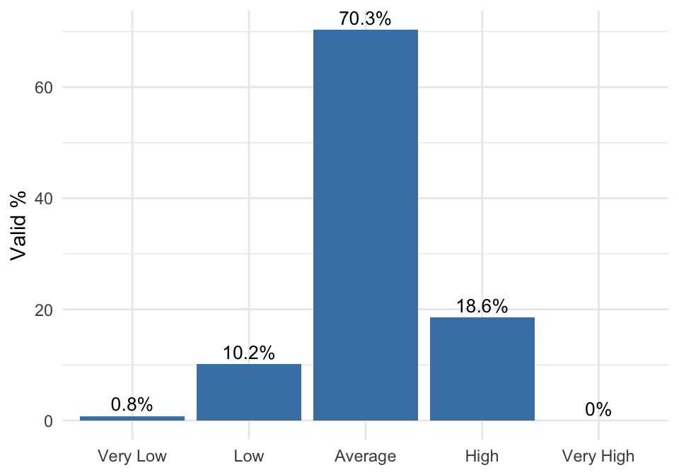

Figure 1: Members’ opinion about savings rates (Q7r)

## R1: One-Sample t-test & Insight

Table 3: One-sample t-test for Q7r (test value = 3, Average)

| Item | n | Mean | SD | Test value | t | df | p |
| --- | --- | --- | --- | --- | --- | --- | --- |
| Q7r: Rates on share accounts | 118 | 3.07 | 0.57 | 3 | 1.3 | 117 | 0.196 |

**Insight.** Members do not seem to join the credit union because it pays better savings rates. About seven in ten (70.3%) rate the share-account rates as “average.” Only 18.6% see them as high, while 11.0% see them as low (Table 2, Figure 1). The average rating (M = 3.07) does not differ from “average” (t(117) = 1.30, p = .196; Table 3). Savings rates are therefore neither an advantage nor a drawback. The reason people join is more likely the convenience of an employee credit union, its service, or other benefits rather than rates. That idea would need to be checked with other questions.

# R2: Why Do Members Borrow Elsewhere?

## R2: Descriptive Statistics (Q8r & Q30)

Table 4: Opinion about rates charged on borrowed funds (Q8r)

| Response | n | Valid % |
| --- | --- | --- |
| Very Low | 1 | 0.9 |
| Low | 17 | 15.9 |
| Average | 59 | 55.1 |
| High | 26 | 24.3 |
| Very High | 4 | 3.7 |

Table 5: CU loan rates are lower than others (Q30)

| Response | n | Valid % |
| --- | --- | --- |
| Strongly Disagree | 4 | 3.1 |
| Disagree | 27 | 21.1 |
| Uncertain | 59 | 46.1 |
| Agree | 33 | 25.8 |
| Strongly Agree | 5 | 3.9 |

## R2: Loan Rate Perceptions

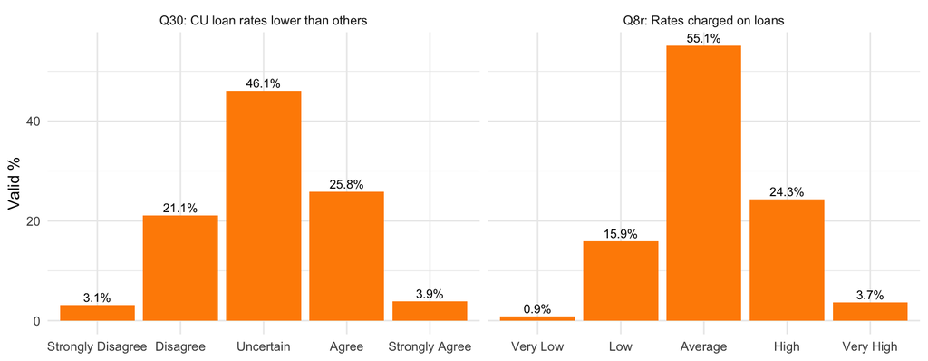

Figure 2: Members’ perceptions of credit union loan rates

## R2: One-Sample t-tests & Insight

Table 6: One-sample t-tests for loan rate items (test value = 3)

| Item | n | Mean | SD | Test value | t | df | p |
| --- | --- | --- | --- | --- | --- | --- | --- |
| Q8r: Rates charged on loans (5 = Very High) | 107 | 3.14 | 0.76 | 3 | 1.91 | 106 | 0.0584 |
| Q30: CU loan rates lower than others (5 = Strongly Agree) | 128 | 3.06 | 0.87 | 3 | 0.82 | 127 | 0.416 |

**Insight.** Members have no clear reason to see the credit union as the cheaper place to borrow. More members think its loan rates are high (28.0%) than low (16.8%), and most (55.1%) call them average (Table 4). Opinions are split on whether CU loan rates beat competitors’: 29.7% agree, 24.2% disagree, and 46.1% are uncertain (Table 5, Figure 2). Neither average differs from the neutral point (Q8r: M = 3.14, t(106) = 1.91, p = .058; Q30: M = 3.06, t(127) = 0.82, p = .416; Table 6). The loan rate advantage that a credit union should have is not reaching members. Also, 21 members had no opinion on loan rates. Together, this suggests members borrow elsewhere because they don’t see a rate advantage here.

# R5: Awareness of Services

## R5: Descriptive Statistics (Q13r – Q26r)

Table 7: Awareness of credit union services (row %, sorted by % unaware)

| Item | Service | Unaware | Aware, not used | Aware & used | Chi-square | df | p |
| --- | --- | --- | --- | --- | --- | --- | --- |
| Q13r | Regular share account | 64.8 | 25.0 | 10.2 | 61.42 | 2 | <0.001 |
| Q25r | IRA loans | 60.9 | 35.9 | 3.1 | 64.56 | 2 | <0.001 |
| Q24r | Share collateralized loans | 53.9 | 44.5 | 1.6 | 59.83 | 2 | <0.001 |
| Q23r | Recreational loans | 43.0 | 46.9 | 10.2 | 31.23 | 2 | <0.001 |
| Q14r | Special subaccounts | 35.9 | 54.7 | 9.4 | 39.81 | 2 | <0.001 |
| Q15r | Christmas club account | 32.8 | 58.6 | 8.6 | 48.02 | 2 | <0.001 |
| Q22r | Household goods/appliance loans | 28.9 | 62.5 | 8.6 | 56.92 | 2 | <0.001 |
| Q16r | Individual Retirement Account | 27.3 | 50.0 | 22.7 | 16.42 | 2 | <0.001 |
| Q21r | Older model car loans | 25.8 | 64.8 | 9.4 | 62.36 | 2 | <0.001 |
| Q17r | MasterCard credit card | 11.7 | 44.5 | 43.8 | 26.92 | 2 | <0.001 |
| Q20r | Late model car loans | 9.4 | 79.7 | 10.9 | 123.81 | 2 | <0.001 |
| Q18r | Signature loans | 3.9 | 81.2 | 14.8 | 134.55 | 2 | <0.001 |
| Q19r | New car loans | 3.9 | 77.3 | 18.8 | 115.80 | 2 | <0.001 |
| Q26r | Line of credit loans | 0.0 | 62.5 | 37.5 | 76.00 | 2 | <0.001 |

## R5: Awareness Profile

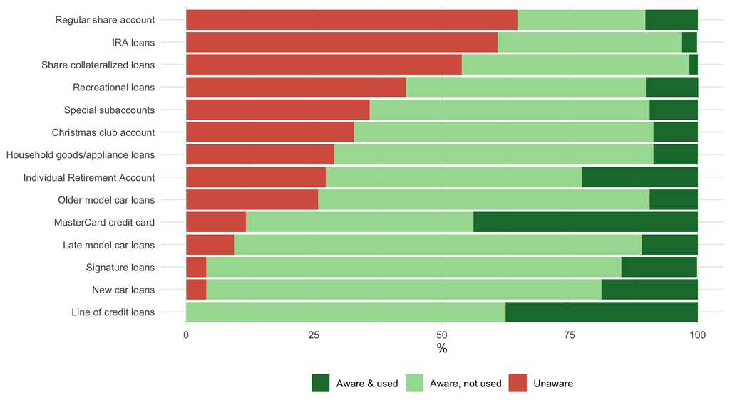

Figure 3: Awareness and use of credit union services

## R5: Insight

**Note**

The coding matches Case Exhibit 31.2 (1 = Aware and have used, 3 = Unaware), yet 64.8% of members say they are unaware of the *regular share account*. Since a share account is normally what makes someone a member, members may not recognize the product by this name. That alone is a communication issue worth raising with the client.